# Part I - Pupil level of study relationship to family stability

## by ALI TRABELSI KAROUI

## Introduction

> The study assesses students’ mathematics, science, and reading skills and contains a wealth of information on students’ background, their school and the organisation of education systems. For most countries, the sample is around 5,000 students, but in some countries the number is even higher. In total, the PISA 2012 dataset contains data on 485 490 pupils.

> Around 510,000 students in 65 economies took part in the PISA 2012 assessment of reading, mathematics and science representing about 28 million 15-year-olds globally. Of those economies, 44 took part in an assessment of creative problem solving and 18 in an assessment of financial literacy.

> The main table is student2012. Pupil performance in mathematics, reading and science is coded by plausible values. You can find them in columns: PV1MATH-PV5MATH (for math), PV1READ-PV5READ (for reading) and PV1SCIE-PV5SCIE (for science). For given area all five values PV1- PV5 are just independent estimations of the student performance in given area. For exploration it is fine to use only PV1.

### What is the structure of your dataset?

> There are 271874 observations for students in the dataset with 16 columns summerising the characteristics of (Kind of Country(OECD), International Grade, Gender, Truancy - Late for School, Truancy - Skip whole school day, Mother, Mother Current Job Status, Father, and Father Current Job Status). Most variables are qualitative in nature, but the variables variables math scores, reading scores, sciences scores, age, wealth, effort, tot_min and final scores are numeric.

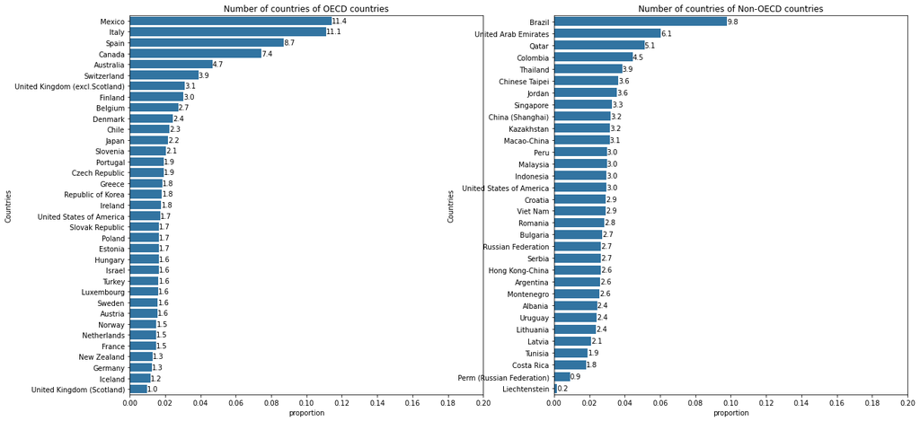

The observatins inside each category of countries differ from one country to another. United kingdoms presents more than 4% because it has the observation with scotland and without scotland. For non-OECD countries, Brazil has the highest proportion of the total distribution, which is better than other wealthy countries like China or Croatia

#### OECD countries Data Distribution

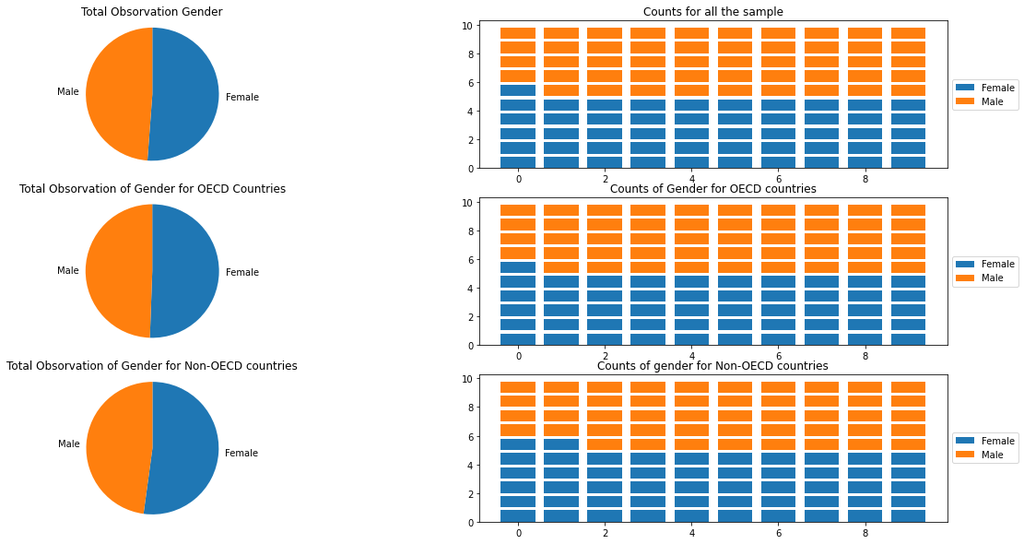

The distribution of gender in the sample is equal in total, which leads to more accurate analysis and fair results for both genders. Whereas the observations for the OECD countries hold equal number of Males and Females, non-OECD members have less equilibriate share from the both genders, with Females presents a higher share.

## Bivariate Exploration

> In this section, I investigate relationships between pairs of variables in your data. Make sure the variables that you cover here have been introduced in some fashion in the previous section (univariate exploration).

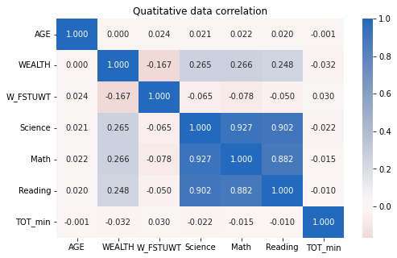

> The results tests whether the numeric values with high correlation. We can sethat exams results for Math science and reading are highly correlated. Instead the final result is negatively corraleted with the exams and not highly significant. In the other side, Age does not show a great dependence with the results shown in the correlation histogram. Wealth results depicts iportant features in term of the correlation with the different exams and negtively correlated with the final result.

### Categorical and Quantitative data

#### Late, Gender and countries' category

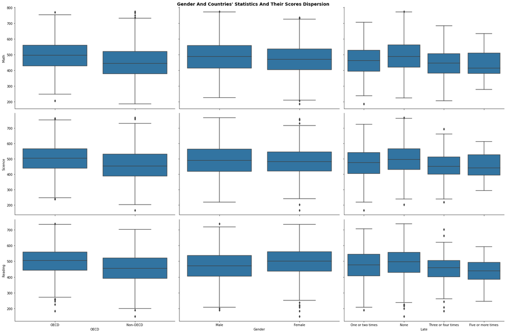

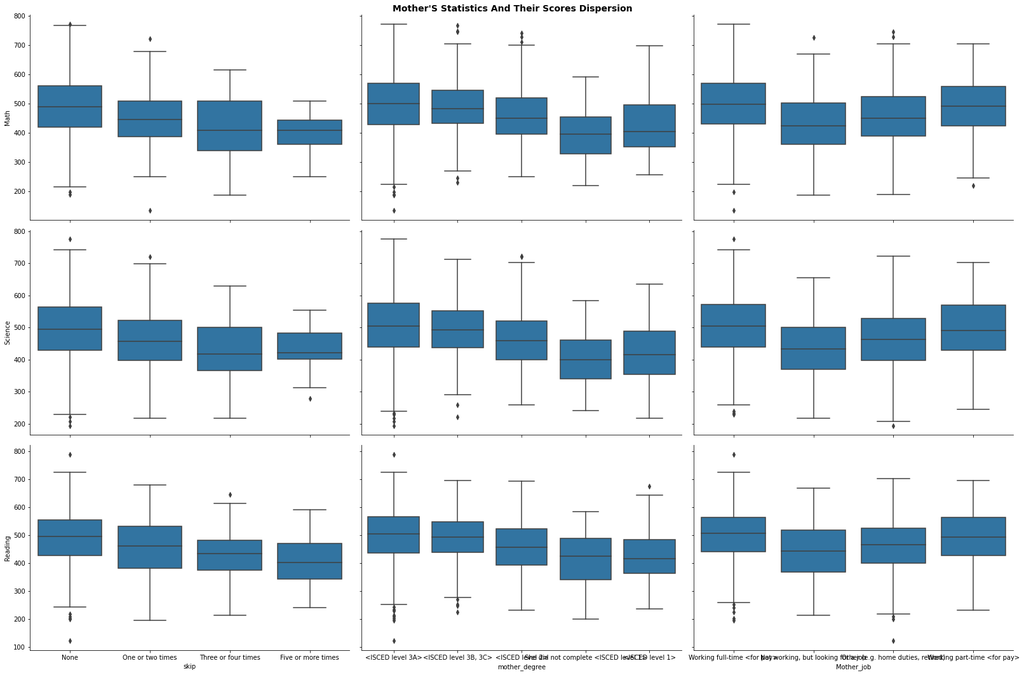

#### Quatitative data relationship to fathers' specificities

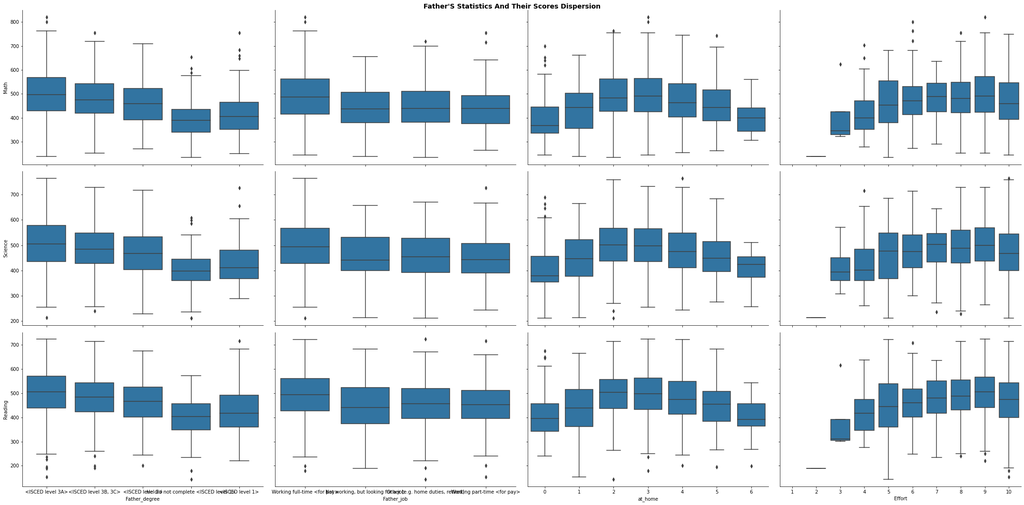

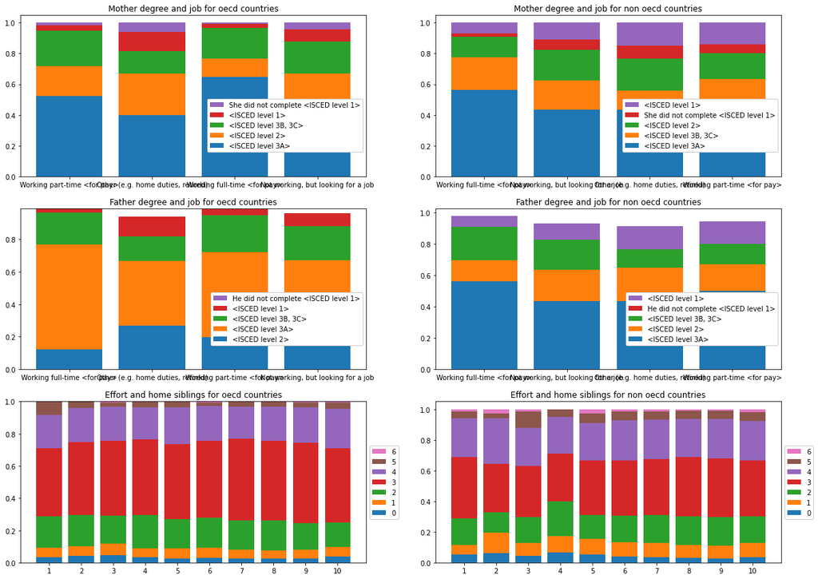

#### Role of wealth for education

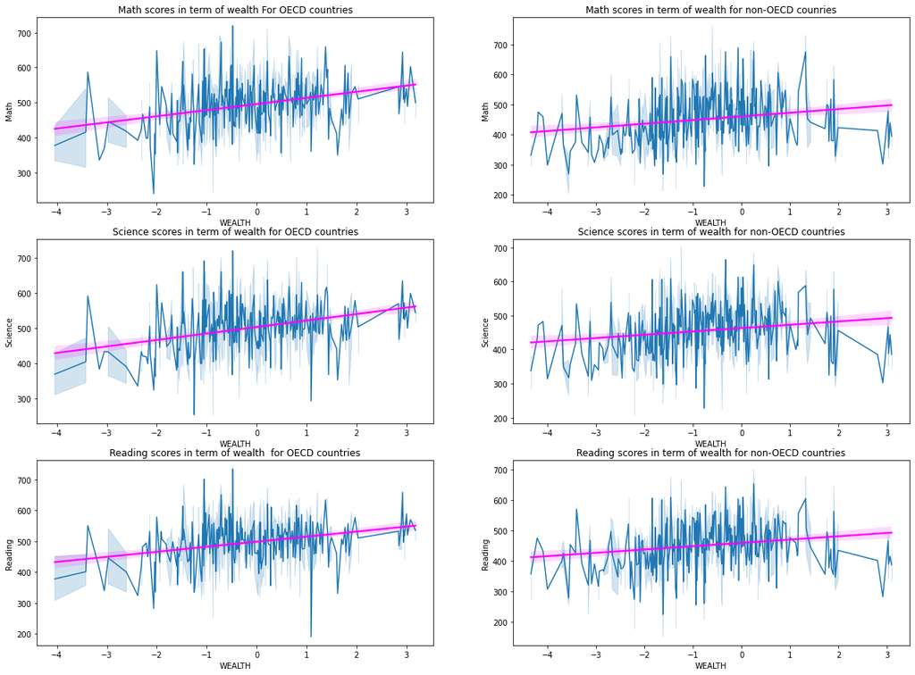

> Subjects results like Maths, science and reading are not infuenced by the degree of weight for all the elements got for the students or the features. We ca see that wealth play a key role in getting better results and it is positevely linear correlated for better high values in each subject. For the OECD countries, the allur of the line is sharper, beacuse the higher the wealth, the better the level of education which is caused by capitalism. In the other hand, the allure of the line is less sharper for the non-OECD countries, which indicates more independence between the wealth and the level in studies. Math and science for the OECd countries depicts more dependence on the wealth for higher reults.

## Multivariate Exploration

> In this section we explore the multi dimentional relationship between the diffrent quanitative variable under diffrent assumptions using the categorical data.

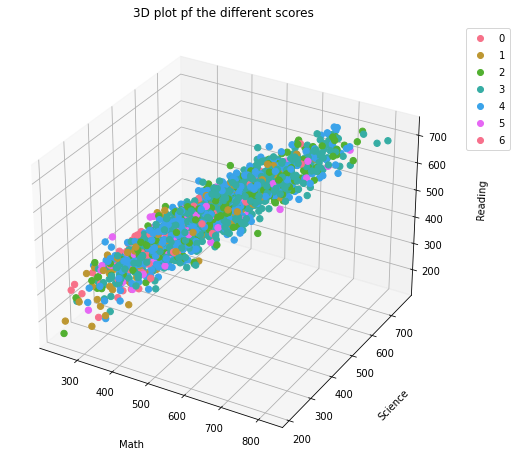

> Most of the distribution is related to the three types of subjects, where an improvement in of them leads to more and high degree in the other two. We can see that some students could be good in math, but they have low degree in science and reading. Otherwise, most of the high resultys in term of ecience and maths have better conditions in term of the number of family member they live with. The 3D plot finds that the worst grades in maths have math have the same conditions in term of family stability with the highest values.

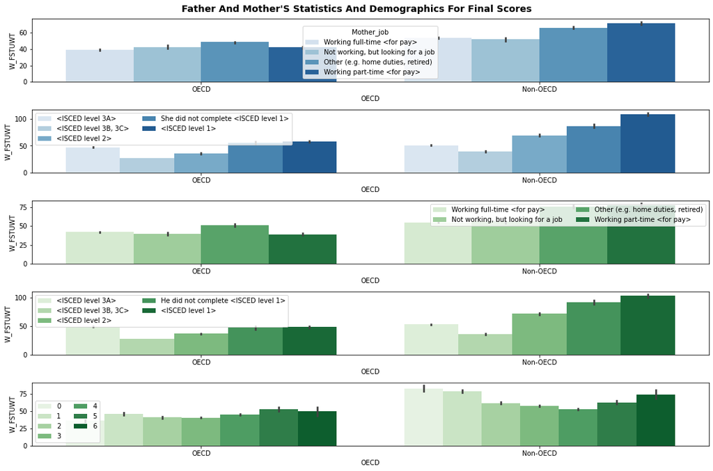

## Conclusions

> Qualitative studies are always limited to the conditions and time zone in which they were generated. Our results could show that wealth could play an imprtant role alongside the home conditions. But in rality, we could see that even homeless and extreme condistions could lead to high results.